# March 2026 Newsletter

| **AP-LS Monthly Newsletter** |
| --- |

| **Facebook \| Blue Sky \| LinkedIn** |
| --- |

[figure not shown]

**Welcome to the March** **2026**

**American Psychology-Law Society (AP-LS) Newsletter**

Our monthly Newsletter provides information about activities, upcoming events, and resources to connect the psychology-law community.

AP-LS aspires to excel as a valuable, effective, and influential organization advancing the science of psychology-law and the translation of psychology-law knowledge into practice and policy.

[figure not shown]

## **Register for Preconference Workshops**

Kick off the AP-LS 2026 conference by attending a preconference workshop on Wednesday, March 11th! Join us for half or full day workshops on psychology and law considerations for aging defendants, mental state at the time of the offense, AI, applications of the Americans with Disabilities Act (ADA), combating bias, and correctional psychology. Check out all the details and register here: **https://buff.ly/x3GF2WP**

Email the CE Committee Chairs with any questions: **ce@ap-ls.org**

## **Building Your Professional and Personal Life: Considerations for Saying “Yes” and Saying “No.”**

**Early Career Professionals Committee Sponsored Session**

Join the Early Career Professionals Committee at the upcoming AP-LS conference for their sponsored session at 4:10pm on Saturday in Tuscany 2!

**Abstract:** Early career professionals are faced with a plethora of decisions upon graduation. While the immense career opportunities awaiting us may be exciting, knowing which opportunities to accept can be daunting. The current session provides attendees a chance to hear from professionals from across the career span about when they have chosen to say, “yes,” when they have chosen to say, “no,” and how they came to those conclusions amid their emerging professional identities. Discussion panel members will include clinical psychologists, academics, and legal scholars who will speak to a range of choices they have faced during their careers, and the considerations they weighed in the process.

# **Legal Update: The “Kavanaugh Stop”: Race, Reasonable Suspicion, and Implicit Bias in Immigration Enforcement**

Immigration and Customs Enforcement (ICE) has recently increased efforts to combat unlawful status in the United States. Their efforts have led to litigation alleging factors related to apparent race or ethnicity do not establish sufficient justification for seizing people. This Legal Update summarizes the Fourth Amendment law around seizures of individuals and describes pending litigation out of California in *Noem v. Vasquez Perdomo*. The Legal Update concludes with research on racial bias in policing and a call for further research. Read more **HERE**.

# **Outstanding Teaching and Mentoring Awards**

[output not shown]

2026 Dissertation Award Winners

| Congratulations to our 2026 AP-LS Dissertation Award Winners! |
| --- |

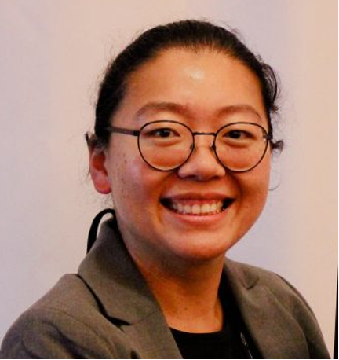

Dr. Sandy S. Xie (Rutgers University – Newark School of Criminal Justice) received First Place for her dissertation, Perceptions of Neuroscience and Mental Health in Courts: Implications of Bias, Stigma, and Other Factors on Defendant Outcomes. Masked reviewers emphasized the methodological breadth of the three-paper approach to examine bias in expert testimony, stigma toward mental illness, and professional perspectives in neurocriminology., noting that the studies varied in design and goals yet “all work together in combination to create a very strong dissertation.” Reviewers highlighted that the work “advances our knowledge of the use of neuroscientific and mental health information in the court system through a variety of angles,” and underscored the applied implications of examining how expert witness race and mental health stigma shape perceptions and defendant outcomes. Dr. Xie completed this dissertation under the supervision of Dr. Colleen Berryessa.

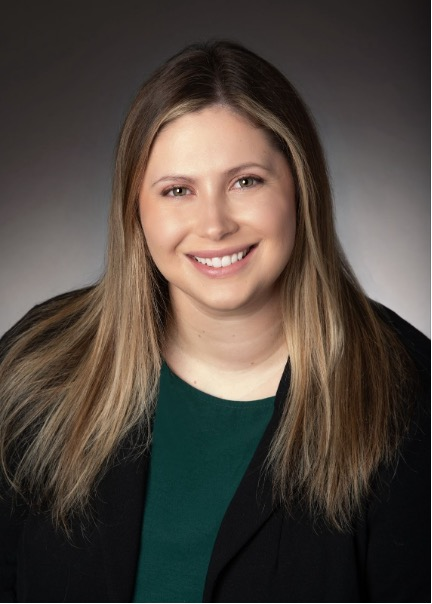

Dr. Samantha Rae Bean (Arizona State University) received Second Place for her dissertation, No Numbers, No Problem? How Mock Jurors Award Noneconomic Damages With and Without Numeric Guidance. Masked reviewers highlighted the dissertation’s careful two-study design, which combined secondary data analysis with a preregistered experimental study to examine how jurors make award decisions with and without numerical anchors. They praised the thorough statistical approach, including the use of log transformations to address skewed distributions, and noted that the project extends the literature on external anchors by testing whether individual difference factors exert stronger influence when guidance is absent versus present. Reviewers described the studies as well-designed and analytically detailed, emphasizing that the findings have direct implications for legal policy debates regarding numerical guidance in civil cases. Dr. Bean completed this dissertation under the supervision of Dr. Jessica Salerno.

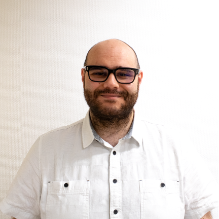

Dr. Luca Adolfo Tiberi (University of Mons) received Third Place for his dissertation, Multi-channel Assessment of Emotion Recognition in Forensic Inpatients who have Committed Sexual Offenses. Masked reviewers described the dissertation as methodologically innovative in integrating facial, prosodic, and bodily emotion recognition within a single coherent framework applied to a forensic inpatient population. They emphasized that the incorporation of signal detection theory, Bayesian approaches, and process-level indices (i.e., sensitivity, response bias, reaction and reflection time, and perceived task difficulty) represented a substantial methodological advance beyond prior work relying primarily on static facial stimuli and mean accuracy scores. Reviewers further noted the dissertation’s exceptional thoroughness, transparent analytic strategies, and careful attention to ecological and construct validity, describing the work as reflecting a high level of scientific maturity and quality of execution. Dr. Tiberi completed this dissertation under the supervision of Prof. Thierry Pham Hoang and Prof. Audrey Vicenzutto.

REID Research Awards

The AP-LS Research Committee is pleased to announce the awardees of the 2025 AP-LS Grant Initiative on Research to Enhance the Impact and Diversification (REID) of Psychology and Law Research. Congratulations to all awardees!

Project PIs: Becky Earhart & Jenny Katsirdakis, Vancouver Island University

Project Title: Facial Recognition as a Mediator of Autistic Differences in Destination Memory

Award: $5,000

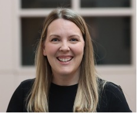

Abstract: Children alleging abuse are often asked in court about disclosure conversations (Stolzenberg & Lyon, 2014), and answering such questions relies on destination memory: remembering who you told something to (Gopie & MacLeod, 2009). Autistic children experience higher than average rates of adverse childhood experiences (Hartley et al., 2024), so understanding destination memory development in this population has important forensic implications.However, destination memory has not been studied in relation to autism. Current research paradigms rely heavily on verbal communication and facial recognition skills, which are known to develop differently in Autistic children (Griffin et al., 2021). The proposed study will investigate differences in destination memory between Autistic and allistic (non-autistic) children, and explore whether facial recognition ability is a mediator of group differences in destination memory. Participants will be 60 Autistic children aged 7 to 12 and 60 allistic children matched on age and gender. Children will participate in interactive conversations with two actors via pre-recorded video clips. Next, participants will complete the Cambridge Face Memory Test for Children (CFMT-C), a validated tool for measuring facial recognition in childhood (Croydon et al., 2014). Finally, participants will complete a destination memory test about the prior conversations in which they will be asked which person they told specific information to. To increase methodological inclusion, a communication board and visual aids will be provided for all participants to reduce demands on verbal skills. A mediation analysis will assess the hypothesis that Autistic participants will show differences in performance on the destination memory test that are mediated by facial recognition ability. The proposed research investigates a new and understudied topic in psychology and law within a novel population. This line of research lays the foundation for future work that has potential for impact in the legal field with respect to how child witnesses are questioned about prior conversations. Given that developmental work on destination memory is still in its infancy, this project has the potential to impact the trajectory of work in this area, encouraging other researchers to consider inclusivity in designing future experiments. This project is a collaboration between a scholar with expertise in destination memory and an Autistic researcher, and the research team is committed to core principles of respectful community engagement, the development of trust in a historically excluded population, and driving impactful changes to the research landscape. We recognize the importance of Autistic voices in research about autism, and highlighting the perspectives of researchers from underrepresented groups.This project has engaged a cross-disciplinary approach, including consultation with an interdisciplinary steering committee that offered community input from various professional and lived experience perspectives that shaped the research methodology. This study also has potential for cross-disciplinary impact in forensic investigations, education, social communication, parenting, and clinical contexts. Supporting practitioners in learning how best to interact with and elicit evidence from both typically developing children and divergent children would improve the experience of all children in the legal system, increasing the likelihood that they will feel heard and respected regardless of diagnostic labels.

[output not shown]

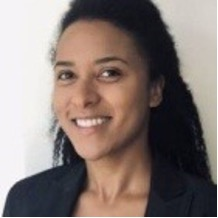

Abstract: Youth involved in the justice system experience disproportionately high rates of learning and developmental disabilities. Yet the medical and behavioral health supports they require are frequently missed, inconsistently documented, and poorly coordinated across child-serving systems. When disability-related concerns are not clearly recognized or documented in medical records, behaviors linked to learning difficulties, trauma responses, or neurodevelopmental conditions may be interpreted as defiance or noncompliance, shaping how youth are treated in clinical, educational, and legal settings. Despite the central role of the electronic health record (EHR) in coordinating care, little empirical work in psychology and law has examined how documentation practices, language, and referral follow-through influence identification and continuity of services for justice-involved youth. To address this gap, this study advances research across developmental psychology, law, education, and medicine by examining a critical yet understudied mechanism: how clinical documentation shapes the identification, interpretation, and referral of youth needs across systems. With a multidisciplinary team spanning adolescent medicine, bioinformatics, developmental psychology, education, and juvenile justice, we will analyze an exploratory sample of 300 adolescents (ages 10-18) with documented histories of juvenile detention who received care within a large academic health system between 2018 and 2025, with plans to expand the cohort as our EHR-based identification strategies are refined. Our project will examine how youth needs are represented in the medical record. Specifically, we will assess the documentation of key educational and clinical supports, such as individualized education programs (IEPs), school reentry plans, psychoeducational evaluations, and behavioral health referrals, and analyze the language clinicians use to describe those needs. These analyses will identify where information is missing, inconsistently recorded, or framed in ways that may influence decision-making across systems. Specifically, we will: (1) quantify gaps in documenting care needs, referrals, and completion of recommended services; (2) apply natural language processing to identify stigmatizing or pathologizing terminology and evaluate associations with service uptake, continuity of care, and re-detention; and (3) use these findings to initiate human-centered design sessions with youth, caregivers, clinicians, education advocates, and justice partners to co-develop preliminary documentation guidelines, standardized communication pathways, and cross-system data sharing templates. Ongoing statewide efforts to modernize EHR systems for detained youth make this an especially timely opportunity to generate evidence that can inform cross-system policy reform. Through examination of how documentation structure and clinical language shape the identification and continuity of care for justice-involved youth, this work aims to contribute to psychology and law while fostering cross-disciplinary collaboration with education and clinical care. By identifying modifiable points in the documentation process and generating potential human-centered solutions, the project aims to inform training standards, strengthen cross-system coordination, and ultimately support improved outcomes for justice-involved youth across clinical, educational, and legal settings.

[output not shown]

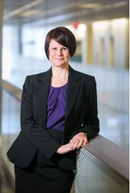

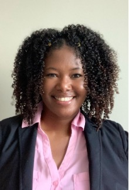

Abstract: Body-worn camera (BWC) programs were marketed as a method to improve transparency, providing objective recordings of interactions between police and community members. However, for many, the promise of BWCs has not been realized. The footage is frequently not released or not released in a timely fashion, and in a new development, not released in its original form. Police departments nationwide have started releasing edited versions of BWC footage that include narration, selective editing, and other contextual materials like Google map overlays. Despite the growing prevalence of these highlight reel videos, there has been no empirical research on the extent to which these common editing practices shape public interpretation, memory, and judgments in officer-involved shootings. Our preliminary data show that these edited highlight reels affect people without their knowledge. Participants who watched a replica of a police highlight reel came away with the most positive interpretations of the officer’s actions and the most negative interpretations of the civilian, compared to other forms of editing. Perhaps most importantly, these participants were strongly opposed to BWC footage being edited, yet simultaneously did not identify the edits in the highlight reel. These results were the seed for our proposed research. Using real BWC footage from an officer-involved shooting case, we propose to test the extent to which specific editing strategies influence public interpretation of an incident and what people later recall about that incident. Experiment 1 will examine five editing techniques currently being used in police departments to assess whether participants recognize editing and how the videos impact perceptions of civilian and officer behavior. For this study, we aim to recruit lawyers, students, and members of the general public to identify patterns across various samples. In Experiment 2, we investigate whether role-based schemas change what viewers encode and later remember about highlight reel videos. Then, in Experiment 3 we propose to test an easily implementable intervention, by examining whether warnings before the video reduce the biased interpretations we observed in our pilot study. Overall, our proposal integrates classic cognitive and social psychology theories such as framing, schema, and inoculation, which have yet to be applied to BWC research. Additionally, the project includes real BWC footage from a U.S. jurisdiction that we had professionally edited in line with police editing practices. Thus, we have a rich set of materials that offer both ecological validity and experimental control. Furthermore, our proposal expands beyond simply documenting an issue to testing a potential simple intervention that could inform policy decisions. Finally, our proposal would contribute to the REID initiative given that BWC footage is both understudied and a significant source of evidence in today’s courts. It is also worth noting that one of the Co-PIs is, as a Black woman, from an underrepresented group in our discipline, and the funding would significantly benefit her career development. Ultimately, we think our proposal offers the beginnings of a fruitful and important line of research to the field of psychology and the law.

BRIDGE Diversity in Psychology and Law Research Awards

The AP-LS Broadening Representation, Inclusivity, Diversity, and Gender Equity (BRIDGE) is pleased to announce the awardees of the 2026 Diversity in Psychology and Law Research Awards. This award supports student research on psycho-legal issues related to diversity or conducted by individuals from underrepresented groups. Each awardee has received a grant of $2000 to support their research. Congratulations to all awardees!

| Raquel Anderson Advancing Indigenous-Led Research through Collaborative Grant Writing: A Case Study of the 2025 Cultural Safety Retreat |
| --- |

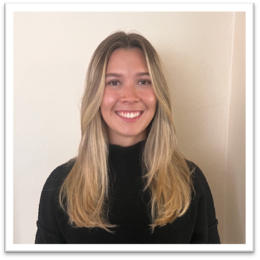

Raquel Anderson is a member of West Moberly First Nations, located in northeastern British Columbia, Canada, with mixed Dunne-Za, Cree, and European settler ancestry. Her research interests include forensic mental health, cultural safety, and the lived experiences of Indigenous populations within the criminal legal system. Currently, Raquel works as the Partnership Coordinator for the Cultural Safety Project, an international collaboration spanning British Columbia, Manitoba, Québec, and Aotearoa New Zealand. The project is committed to advancing cultural safety in forensic mental health. In this role, Raquel facilitates communication among partners and collaborators across regions and supports project coordination to ensure the partnership’s success. She intends to pursue graduate studies in clinical forensic psychology.

| Renée Beach Disability Type and Preferential Hierarchy in Civil Negligence Cases |
| --- |

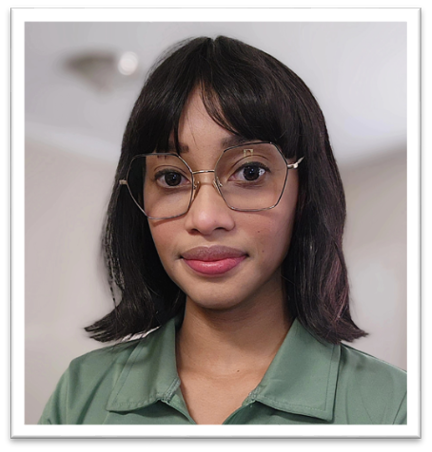

Renée Beach, B.S., is a second-year Clinical Psychology-Law PhD student at The University of Alabama. Her current research examines preferential hierarchy based on disability type in civil litigation, and her broader research interests include bias in judicial procedure, legal decision-making, and forensic mental health assessment. Ms. Beach’s experiences as a disabled Black woman, immigrant, and first-generation college student have fostered a dedication to inclusion, equity, and accessibility that inform her activities as a scholar, researcher, and community advocate. Beyond her scholarship, she is currently a co-leader and special project manager for the Disability Advocacy and Research Network and a member of the American Psychological Association’s Policy and Planning Board. Through her research and advocacy, she hopes to challenge systemic inequities and expand understanding of how identity and bias intersect within legal contexts.

| Kaiden Kaba Parenting Style and Adolescents’ Interrogation- and Plea-Related Legal Decisions |
| --- |

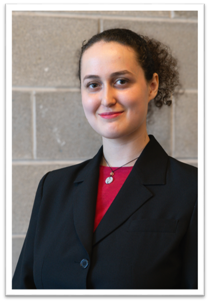

Kaiden is a second year Master’s student studying Forensic Psychology at Ontario Tech University. Working under Dr. Lindsay Malloy, they are currently exploring the factors that impact youth legal decision-making in their project entitled, “Parenting Style and Adolescents’ Interrogation- and Plea-Related Legal Decisions”. Motivated to get a Doctorate in Forensic Psychology, they hope to pursue a career in researching youths’ legal decisions as they navigate the Criminal Justice System.

| Alexey Mazon Mock Jurors’ Perceptions of Latinx Plaintiffs: Do Skin Tones and Accents Impact Damage Awards? |
| --- |

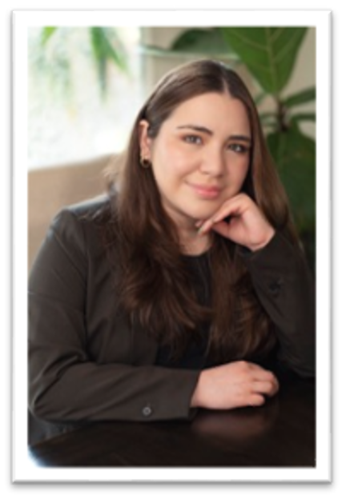

Alexey Mazon, B.S., B.A., is a Ph.D. student studying Psychology with an emphasis in Law at the University of Wyoming under the mentorship of Dr. Hannah J. Phalen and is projected to graduate in May 2028. Her research interests focus on how race/ethnicity, gender, and sexuality might impact marginalized individuals’ experiences with the civil legal system. Her experience as a Salvadoran American informed her work on her master's thesis involving perceptions of a Latinx immigrant in a mock employment case. Upon graduation she hopes to work as a trial consultant.

| Aaron Palachi Psycholegal Perspectives on Intimate Partner Violence in Sexual and Gender Minority Communities: Validating Measurement and Examining Help-Seeking |
| --- |

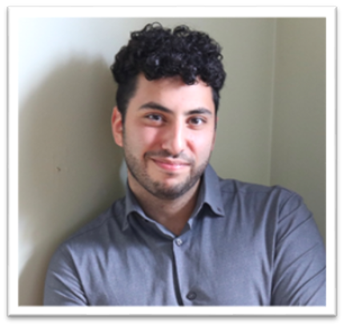

Aaron Palachi is a PhD student in the Clinical Psychology program at Toronto Metropolitan University (TMU), supervised by Dr. David Day. His research interests broadly focus on trauma, adversity, and psychosocial wellbeing among underserved and equity-deserving populations, with particular attention to how experiences of violence intersect with psychological and legal service systems. His doctoral dissertation examines measurement practices for intimate partner violence among sexual and gender minority populations, and the influence of human agency and mental health on help-seeking behaviours. Aaron earned his Master of Arts in Psychology at TMU and his Bachelor of Arts in Psychology at York University. Clinically, Aaron works with both adults and adolescents presenting with a range of concerns including mood and anxiety-related disorders, trauma, and severe and persistent mental illness.

# **Consider Joining the Spanish-Speaking Forensic Psychology Network**

[figure not shown]

Achieving Economic Stability: Leveraging Psychological Science to Advance Economic Justice

Monday, March 2 at 12:00 PM ET

Click to register

In this first webinar, Achieving Economic Stability, authors from the Society for the Psychological Study of Social Issues (SPSSI, APA Division 9) and Psychology of Social Class Organization (POSCO) examine complementary policy proposals that could shift the day-to-day reality of millions of Americans from economic precarity to economic stability.

Speakers:

- Heather E. Bullock, Director of the Center for Economic Justice and Action and Professor of Psychology at the University of California, Santa Cruz.
- Harmony A. Reppond, Associate Professor of Psychology at the University of Michigan, Dearborn.
- Klaus E. Cavalhieri, Assistant Professor of Counseling Psychology at the University at Albany, State University of New York.

Register here

Rethinking Inequality: Leveraging Psychological Science to Advance Economic Justice is a collaboration of the Society for the Psychological Study of Social Issues, the Division on Adult Development and Aging, the Society for the Psychology of Women, the Society for Child and Family Policy and Practice, the Society for Health Psychology, the American Psychology-Law Society, and the Psychology of Social Class Organization, with support from the American Psychological Association (APA) Committee on Division/APA Relations.

Any opinions or conclusions expressed in this volume or webinar series are those of the individual contributors and do not reflect the views of the participating organizations, the American Psychological Association, or any of their divisions or subunits.

Call for applications for the Grant-in-Aid for Early Career Professionals

The Early Career Professionals Committee is opening a call for Grants-in-Aid for Early Career Professionals. The purpose of this award is to support AP-LS members who are ECPs in conducting research related to psychology and law. It is the committee’s desire that these awards are not limited only to members who are psychologists, but instead open to AP-LS members from all backgrounds. The deadline for submissions is May 15. The purpose of this award is to support AP-LS members who are ECPs in conducting research related to psychology and law. It is the committee’s desire that these awards are not limited only to members who are psychologists, but instead open to AP-LS members from all backgrounds. Applications are open to all AP-LS members who are within ten years of receiving their last degree. For further information regarding eligibility criteria, proposal guidelines and templates, please visit: https://ap-ls.org/awards/grants/ecgrantinaid.

American Academy of Forensic Psychology Dissertation Grants in Applied Law/Psychology

A committee of AAFP fellows reviews applications and grants of up to $2,000 will be awarded based on the following criteria:

- Potential contribution of the dissertation to applied law-psychology
- Methodological soundness/experimental design
- Budgetary needs, review of applicant’s personal statement

Students in the process of developing a dissertation proposal and those collecting dissertation data as of April 14, 2026 are eligible for the grants for the coming year.*

To apply, students must submit electronic copies of the following no later than April 14, 2026 (incomplete applications will not be considered):

- A letter from the applicant including:
- - A summary of interest and career goals in the area of law and psychology
  - The proposed research and its timeline
  - The dissertation budget, award amount requested, and how the award will be used
  - Current status of approval from the relevant committees and IRB (funds cannot be awarded until IRB approval is complete, if necessary).
- A current CV
- A letter (no longer than one page) from the applicant's dissertation chair/supervisor offering their support of the applicant, confirming that the dissertation proposal has been or is expected to be approved and will be conducted as detailed in the applicant's letter.

*Please note that this is a grant for original research, rather than an award for research that has been completed.

Newsletter Editor Position

AP-LS is seeking applications for the position of Newsletter Editor. The 3-year term begins in August, 2026. This is a non-voting appointment on the AP-LS Executive Committee.

Each month, the Editor solicits news submissions from the AP-LS leadership. The Editor will work closely with the Associate Editor, Taylor Petty, who coordinates regular column submissions from content editors (i.e., Research Briefs, Legal Update, Teaching in Psych & Law, Career Corner, and Clinical & Forensic Practice). Interested individuals are encouraged to contact the outgoing Editor Meg Ternes (meg.ternes@smu.ca) to discuss the position.

To apply, please send a cover letter and Curriculum Vita to Chair of the Communications Committee, Ana Belmonte: webeditor@ap-ls.org

The application deadline is April 15, 2026.

Call for Book Proposals

The American Psychology-Law Society invites proposals for new titles in its book series, which is now published by Oxford University Press. We publish authored and edited volumes on current issues at the intersection of psychology and law. Books are typically a state of the science synthesis of a body of existing research with implications for practice and/or policy. Authors and editors should have a substantial and recent track record of publication and/or practice in psychology or law, and at least one should hold a doctorate in psychology or closely related behavioral science. If you have a proposal for a new book in the series or you would simply like more information, please reach out to a member of the editorial team. We would be happy to discuss possible topics and fit for the series. Inquiries are accepted on a rolling basis.

The editorial board members are:

- Monica Miller, Division 41 Book Series Editor (mkmiller@unr.edu)
- Monique Bowen, Division 41 Book Series Associate Editor (mbowen2@antioch.edu)
- Dan Murrie, Division 41 Book Series Associate Editor (dcm3w@uvahealth.org)
- Lora Levett, Division 41 Book Series Associate Editor (llevett@ufl.edu)

Request for Proposals for Chapters and Essays

Monica K. Miller, David DeMatteo, and Daniel Krauss are editors of the book series

“Advances in Psychology and Law,” which seeks to enhance understanding of the connections between these disciplines, present “state of the science” summaries for current researchers, and provide a starting point for scholars wanting to delve into a new topic of study by reading an up-to-date review chapter or brief essay on that topic. All areas of psychology (e.g., developmental, social, cognitive, clinical, neuroscience) and law (e.g., criminal, civil, contracts, property, family) are appropriate for inclusion.

Chapters and essays will be primarily reviews or meta-analyses. Although they might provide some data to illustrate a new phenomenon, they are not meant to be data-driven like a journal article. Review chapters and essays will be on particular topics relevant to psychology and law and will be of current interest to the field. Chapters (and especially essays) will typically summarize research on one particular topic, rather than focusing on the entire body of research in an area (e.g., focusing on the Weapon Focus effect rather than the entire body of eyewitness memory). Chapters will be relatively long (30-40 pages d.s.), which will allow authors to provide in depth analysis and take calculated risks (e.g., engaging in informed speculation about future research or the consequences of particular legal policies). Essays will be shorter (approximately 10 pages d.s.) because they discuss a topic that is new and/or has less previous research to synthesize.

The book series has an editorial board of distinguished scholars who are experts in various areas in psychology and law. The editorial board will offer guidance about the development of topics and serve as expert reviewers of chapters and essays. The editors strive to produce one volume in the series approximately every 12-18 months.

Overviews of the previous volumes can be viewed here to ensure topics have not been already included in the series and to see examples of chapters: http://www.springer.com/series/11918?detailsPage=titles

Submit an approximately 300 word description and title of your proposed topic and indicate if you want to write an essay or chapter. Specify both the legal component and the psychological component of your topic. Inquiries are accepted on a rolling basis. Email submissions to Monica Miller at mkmiller@unr.edu.

AP-LS Student Committee’s New Mentorship Program

The AP-LS Student Committee is launching a new mentorship program! Sign up here: https://forms.gle/GDXnreiPd5ciBtrn9

We’re excited to launch a supportive, community-driven mentorship program designed to connect emerging scholars with experienced peers in the field. Participants can sign up either as mentors, open to anyone in their second year or beyond in a graduate program or as mentees, including undergraduates, prospective applicants, and first-year graduate students (or those about to begin). Because this program is new, we’ll be learning and shaping it together. We anticipate bi-annual virtual meetings for mentors and mentees, and we ask that mentors remain available throughout the year for occasional emails or smaller questions that may arise. The commitment is one year minimum, with the option to continue as long as you’d like. We’ll do our best to match participants thoughtfully, though there may be a brief waiting list as we get the program up and running. We appreciate your enthusiasm and patience and we can’t wait to build this community with you!

**Executive Committee**

| For more information or if you wish to contact a member of the AP-LS Executive Committee, details can be found **HERE.** |
| --- |

## **On The Job or Postdoc Market? AP-LS Job Postings**

| Check out **AP-LS's Job Postings Page** for up-to-date information on available psychology-law positions. |
| --- |

| View Job Postings |
| --- |

## **Newsletter Editorial Board**

| EDITOR Meg Ternes meg.ternes@smu.ca ASSOCIATE EDITOR Taylor Petty tepetty@usi.edu CONTENT EDITORS–RESEARCH BRIEFS Kelly McWilliams kmcwilliams@jjay.cuny.edu Veronica Johnson vjohnson@jjay.cuny.edu |
| --- |

[output not shown]

## **Membership Services**

[output not shown]

## **Newsletter Archives**

| **Archives of the newsletter are available at https://ap-ls.org/newsletter.** |
| --- |

| **American Psychology-Law Society** www.ap-ls.org \| (704) 456-7276 \| office@ap-ls.org |
| --- |

| *Copyright © American Psychology-Law Society* *Division 41 of the American Psychological Association All rights reserved.* |
| --- |